# Tarea 8 Optimización no lineal - Clemente Ferrer

Instalación de los paquetes.

```r
install.packages(c("mplot", "ISLR", "glmnet", "MASS", "readr",
    "dplyr"))
```

Uso de librerias.

```r
library(mplot)
library(ISLR)
library(glmnet)
library(MASS)
library(readr)
library(dplyr)
```

Lectura del archivo.

```r
url = "https://archive.ics.uci.edu/ml/machine-learning-databases/ionosphere/ionosphere.data"
dat = readr::read_csv(url,col_names = FALSE)
```

Visualización de los datos.

```r
head(dat)
```

| X1 | X2 | X3 | X4 | X5 | X6 | X7 | X8 | X9 | X10 | X11 | X12 | X13 | X14 | X15 | X16 | X17 | X18 | X19 | X20 | X21 | X22 | X23 | X24 | X25 | X26 | X27 | X28 | X29 | X30 | … |
| --- | --- | --- | --- | --- | --- | --- | --- | --- | --- | --- | --- | --- | --- | --- | --- | --- | --- | --- | --- | --- | --- | --- | --- | --- | --- | --- | --- | --- | --- | --- |
| 1 | 0 | 0.99539 | -0.05889 | 0.85243 | 0.02306 | 0.83398 | -0.37708 | 1.00000 | 0.03760 | 0.85243 | -0.17755 | 0.59755 | -0.44945 | 0.60536 | -0.38223 | 0.84356 | -0.38542 | 0.58212 | -0.32192 | 0.56971 | -0.29674 | 0.36946 | -0.47357 | 0.56811 | -0.51171 | 0.41078 | -0.46168 | 0.21266 | -0.34090 | … |
| 1 | 0 | 1.00000 | -0.18829 | 0.93035 | -0.36156 | -0.10868 | -0.93597 | 1.00000 | -0.04549 | 0.50874 | -0.67743 | 0.34432 | -0.69707 | -0.51685 | -0.97515 | 0.05499 | -0.62237 | 0.33109 | -1.00000 | -0.13151 | -0.45300 | -0.18056 | -0.35734 | -0.20332 | -0.26569 | -0.20468 | -0.18401 | -0.19040 | -0.11593 | … |
| 1 | 0 | 1.00000 | -0.03365 | 1.00000 | 0.00485 | 1.00000 | -0.12062 | 0.88965 | 0.01198 | 0.73082 | 0.05346 | 0.85443 | 0.00827 | 0.54591 | 0.00299 | 0.83775 | -0.13644 | 0.75535 | -0.08540 | 0.70887 | -0.27502 | 0.43385 | -0.12062 | 0.57528 | -0.40220 | 0.58984 | -0.22145 | 0.43100 | -0.17365 | … |
| 1 | 0 | 1.00000 | -0.45161 | 1.00000 | 1.00000 | 0.71216 | -1.00000 | 0.00000 | 0.00000 | 0.00000 | 0.00000 | 0.00000 | 0.00000 | -1.00000 | 0.14516 | 0.54094 | -0.39330 | -1.00000 | -0.54467 | -0.69975 | 1.00000 | 0.00000 | 0.00000 | 1.00000 | 0.90695 | 0.51613 | 1.00000 | 1.00000 | -0.20099 | … |
| 1 | 0 | 1.00000 | -0.02401 | 0.94140 | 0.06531 | 0.92106 | -0.23255 | 0.77152 | -0.16399 | 0.52798 | -0.20275 | 0.56409 | -0.00712 | 0.34395 | -0.27457 | 0.52940 | -0.21780 | 0.45107 | -0.17813 | 0.05982 | -0.35575 | 0.02309 | -0.52879 | 0.03286 | -0.65158 | 0.13290 | -0.53206 | 0.02431 | -0.62197 | … |
| 1 | 0 | 0.02337 | -0.00592 | -0.09924 | -0.11949 | -0.00763 | -0.11824 | 0.14706 | 0.06637 | 0.03786 | -0.06302 | 0.00000 | 0.00000 | -0.04572 | -0.15540 | -0.00343 | -0.10196 | -0.11575 | -0.05414 | 0.01838 | 0.03669 | 0.01519 | 0.00888 | 0.03513 | -0.01535 | -0.03240 | 0.09223 | -0.07859 | 0.00732 | … |

Notamos que poseemos 35 columnas, donde las primeras 34 corresponden a nuestra matriz de covariables $\boldsymbol{X}\in\mathbb{R}^{351\times 34}$ y la última a la variable respuesta $\boldsymbol{Y}\in\mathbb{R^{351}}$. Por ello, procedemos a crear los elementos anteriores.

```r
dat = dplyr::rename(dat, y = X35)
dat$y = as.factor(dat$y)
x = as.matrix(dat[,-c(35)])

head(y)
```

```
[1] g b g b g b
Levels: b g
```

```r
head(x)
```

```
     X1 X2      X3       X4       X5       X6       X7       X8      X9
[1,]  1  0 0.99539 -0.05889  0.85243  0.02306  0.83398 -0.37708 1.00000
[2,]  1  0 1.00000 -0.18829  0.93035 -0.36156 -0.10868 -0.93597 1.00000
[3,]  1  0 1.00000 -0.03365  1.00000  0.00485  1.00000 -0.12062 0.88965
[4,]  1  0 1.00000 -0.45161  1.00000  1.00000  0.71216 -1.00000 0.00000
[5,]  1  0 1.00000 -0.02401  0.94140  0.06531  0.92106 -0.23255 0.77152
[6,]  1  0 0.02337 -0.00592 -0.09924 -0.11949 -0.00763 -0.11824 0.14706
          X10     X11      X12     X13      X14      X15      X16      X17
[1,]  0.03760 0.85243 -0.17755 0.59755 -0.44945  0.60536 -0.38223  0.84356
[2,] -0.04549 0.50874 -0.67743 0.34432 -0.69707 -0.51685 -0.97515  0.05499
[3,]  0.01198 0.73082  0.05346 0.85443  0.00827  0.54591  0.00299  0.83775
[4,]  0.00000 0.00000  0.00000 0.00000  0.00000 -1.00000  0.14516  0.54094
[5,] -0.16399 0.52798 -0.20275 0.56409 -0.00712  0.34395 -0.27457  0.52940
[6,]  0.06637 0.03786 -0.06302 0.00000  0.00000 -0.04572 -0.15540 -0.00343
          X18      X19      X20      X21      X22      X23      X24      X25
```

[output cut: 20 more lines]

A continuación creamos la sucesión positiva y creciente $\{\lambda_l\}_{l=1}^{K}$, donde $K=5001$ y $\lambda_1=0$ y $\lambda_{5001}=5$. En particular, estarán equiespaciados, con $h:=\lambda_{l+1}-\lambda_{l}=10^{-3}$.

```r
lambda_seq = seq(0, 5, 0.001)
```

Ahora bien, realizaremos validación cruzada con 10 grupos mediante el comando $\texttt{cv.glmnet}$, el cual al introducir el parámetro $\texttt{family = "binomial"}$ realiza la regresión logística y $\texttt{alpha = 0}$ considera la penalización Ridge. Enseguida realizaremos el gráfico $\text{MSE}\left(\hat{\beta^{l}}\right)\,\text{v/s}\,\{\lambda_l\}_{l=1}^{K}$ y entregaremos el valor $\lambda_{\min}$ que minimiza el error cuadrático medio junto con su valor en logaritmo, es decir, $\log(\lambda_{\min})$.

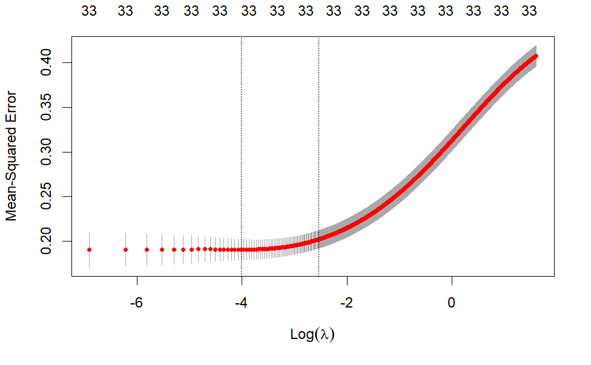

```r
ridge.cv = cv.glmnet(x, y, lambda = lambda_seq, family = "binomial", type.measure = "mse", alpha = 0, nfolds = 10)

plot(ridge.cv)
```

```r
print(ridge.cv$lambda.min)
```

```
[1] 0.018
```

```r
print(log(ridge.cv$lambda.min))
```

```
[1] -4.017384
```

Si consideramos $\texttt{alpha = 1}$ tenemos la penalización LASSO. Realizaremos el mismo procedimiento que el caso anterior.

$\textbf{Observación: }$ El algoritmo que realiza la función $\texttt{cv.glmnet}$ es precisamente el indicado por la tarea para hallar el parámetro $\lambda$. Más aún, la función $\texttt{glmnet}$ está programada usando el método del gradiente proximal.

Fuente: https://cran.r-project.org/web/packages/glmnet/vignettes/glmnet.pdf

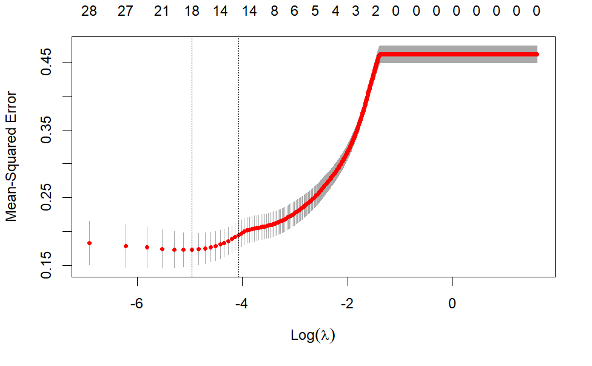

```r
lasso.cv = cv.glmnet(x, y, lambda = lambda_seq, family = "binomial", type.measure = "mse", alpha = 1, nfolds = 10)

plot(lasso.cv)
```

```r
print(lasso.cv$lambda.min)
```

```
[1] 0.007
```

```r
print(log(lasso.cv$lambda.min))
```

```
[1] -4.961845
```

En particular, usando $\lambda_{\min}^{\text{Ridge}}$ asociado a la penalización Ridge, obtenemos los siguientes coeficientes.

```r
ridge.fit.optimal = glmnet(x, y, lambda = ridge.cv$lambda.min,family = "binomial", alpha = 0)
coef(ridge.fit.optimal)
```

```
35 x 1 sparse Matrix of class "dgCMatrix"
                     s0
(Intercept) -5.22749279
X1           3.59466289
X2           .
X3           1.27808754
X4           0.44459921
X5           1.34516824
X6           1.01408822
X7           0.91015962
X8           1.19998347
X9           0.68860494
X10          0.42092186
X11         -0.33488987
X12         -0.06120822
X13         -0.11134478
X14          0.40491987
X15          0.31681976
X16         -0.14144879
X17          0.01450178
X18          0.51547826
X19         -0.31849343
X20          0.02948063
X21          0.18981763
X22         -1.46989600
X23          0.55225409
X24          0.26607181
X25          0.57525868
X26          0.34451385
X27         -1.36387418
X28         -0.10878490
X29          0.35011216
X30          0.74514925
X31          0.57834877
X32         -0.20315798
X33         -0.28008330
X34         -0.99422669
```

Luego, usando $\lambda_{\min}^{\text{LASSO}}$ asociado a la penalización LASSO, obtenemos los siguientes coeficientes.

```r
lasso.fit.optimal = glmnet(x, y, lambda = lasso.cv$lambda.min,family = "binomial", alpha = 1)
coef(lasso.fit.optimal)
```

```
35 x 1 sparse Matrix of class "dgCMatrix"
                     s0
(Intercept) -8.48933909
X1           6.60749442
X2           .
X3           1.66112169
X4           .
X5           1.49136801
X6           1.17876515
X7           1.53086789
X8           1.41357952
X9           .
X10          0.50963884
X11          .
X12          .
X13          .
X14          .
X15          .
X16         -0.05565949
X17          .
X18          0.57006211
X19          .
X20          .
X21          .
X22         -1.65762429
X23          0.26101437
X24          0.23502935
X25          0.82672224
X26          .
X27         -1.58358451
X28          .
X29          0.07565213
X30          1.29151057
X31          0.58594325
X32          .
X33          .
X34         -1.58442526
```

De lo anterior, observamos para la penalización LASSO muchos de los $\hat{\beta}_i ^{\lambda_{\min}^{\text{LASSO}}}$ son $0$, es decir, no son significativos para la regresión del modelo.

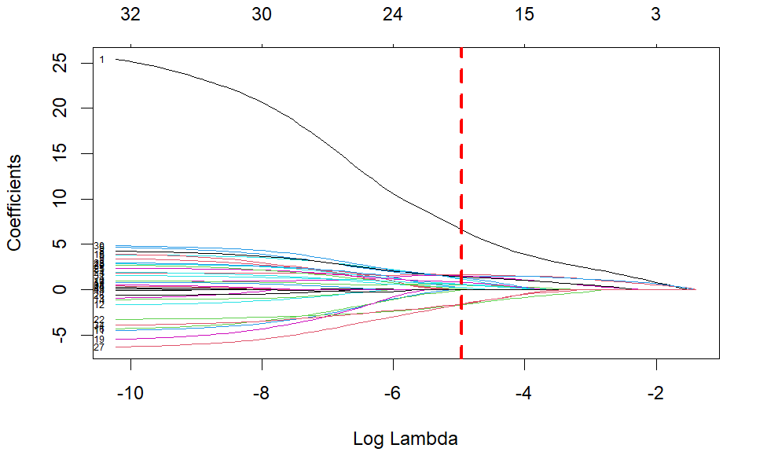

```r
lasso.fit = glmnet(x, y, family = "binomial", alpha = 1)
plot(lasso.fit, xvar = "lambda", label = TRUE)
abline(v = log(lasso.cv$lambda.min), col="red", lwd=3, lty=2)
```